# Dissertation

2022-10-27

# 1 Ave PPMR for individual species, weighted by prey biomass:

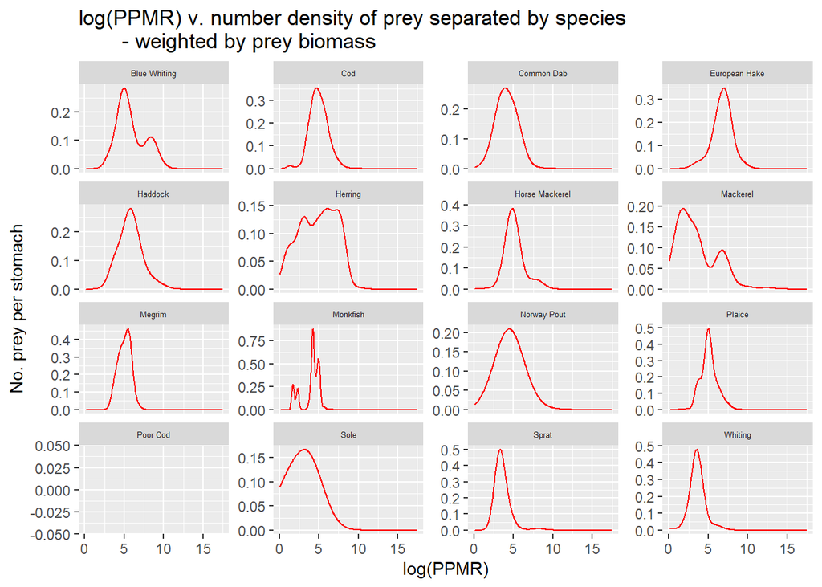

```
## [1] "Herring 848.222200986842 45144.4326899338"
## [1] "Sprat 248.197178912441 51636.4297015514"
## [1] "Cod 295.441882576803 90787.1007298791"
## [1] "Haddock 1135.73893928979 37054.0854782163"
## [1] "Whiting 70.7054471226231 81313.6142003035"
## [1] "Blue Whiting 1663.07476986092 119266.616833277"
## [1] "Norway Pout 170.261552009839 10880.3843655565"
## [1] "Poor Cod 636.000622912304 NA"
## [1] "European Hake 1515.46774193548 2562.12315702252"
## [1] "Monkfish 82.8871413269041 79.8226037284675"
## [1] "Horse Mackerel 379.911650432013 854.782787249371"
## [1] "Mackerel 6810.71105570261 7203551.49824461"
## [1] "Common Dab 119.655456006448 48118.4751476602"
## [1] "Plaice 292.580816659072 14301.7363233075"
## [1] "Megrim 193.278418297033 265.553657586625"
## [1] "Sole 39.7422702144175 23210.2455537281"
## [1] "Boarfish NaN NA"
```

Looking for the most common PPMR for each individual species.

A graph of the weighted ppmr for each species against the number density of the prey. Prints the mean ppmr, as weighted by prey biomass.

# 2 Ave PPMR for individual species, weighted by number of prey:

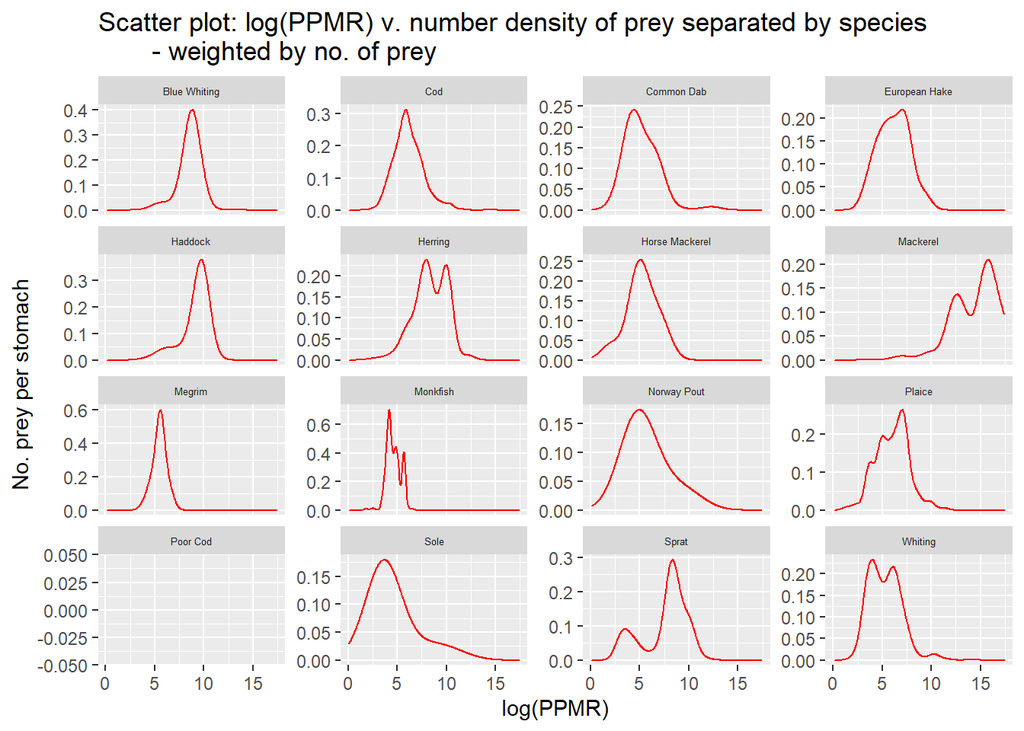

```
## [1] "Herring 13266.6160274221 45144.4326899338"
## [1] "Sprat 8282.72558879623 51636.4297015514"
## [1] "Cod 5287.19491542683 90787.1007298791"
## [1] "Haddock 14958.5796689444 37054.0854782163"
## [1] "Whiting 5206.71287948893 81313.6142003035"
## [1] "Blue Whiting 8935.94023437613 119266.616833277"
## [1] "Norway Pout 2878.69808666309 10880.3843655565"
## [1] "Poor Cod 636.000622912304 NA"
## [1] "European Hake 1359.73380419153 2562.12315702252"
## [1] "Monkfish 129.949289675677 79.8226037284675"
## [1] "Horse Mackerel 464.192193331282 854.782787249371"
## [1] "Mackerel 8058296.51814205 7203551.49824461"
## [1] "Common Dab 4572.01186595249 48118.4751476602"
## [1] "Plaice 1947.19209123781 14301.7363233075"
## [1] "Megrim 285.243221232865 265.553657586625"
## [1] "Sole 3973.38360303677 23210.2455537281"
## [1] "Boarfish NaN NA"
```

Looking for the most common PPMR for each individual species.

A graph of the weighted ppmr for each species against the number density of the prey. Prints the mean ppmr, as weighted by number of prey.

# 3 Specific PPMR calculations by different weightings for Herring species

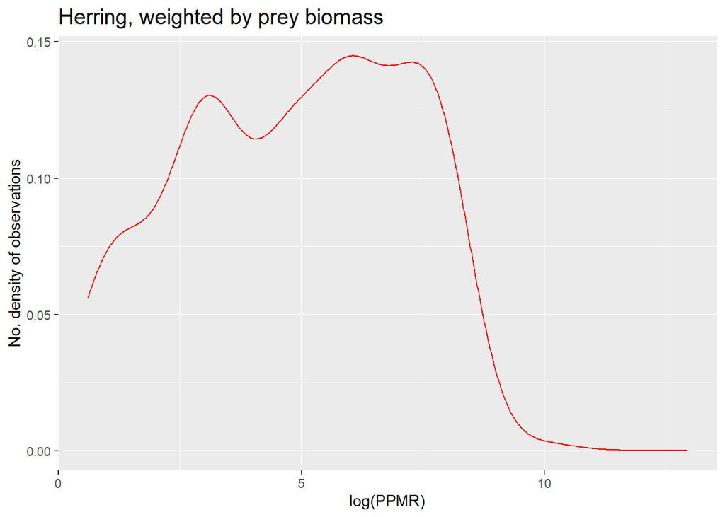

```
## [1] "ave PPMR weighted by prey biomass: 848.222200986842"
```

```
## [1] "standard deviation: 45144.4326899338"
```

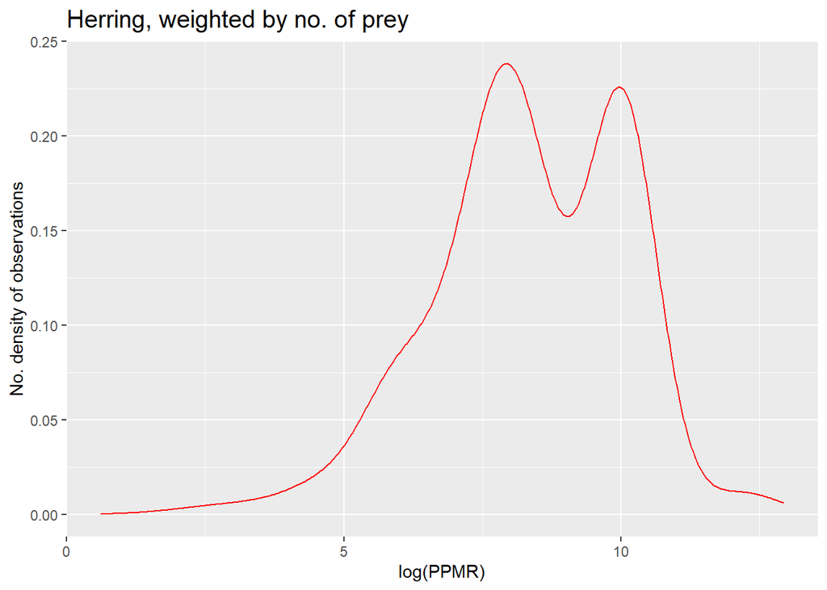

```
## [1] "ave PPMR weighted by no. of prey: 13266.6160274221"
```

```
## [1] "standard deviation: 45144.4326899338"
```

# 4 prey weight v. number density of prey

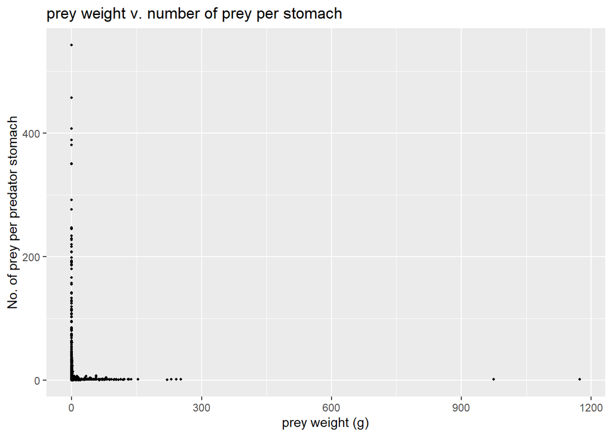

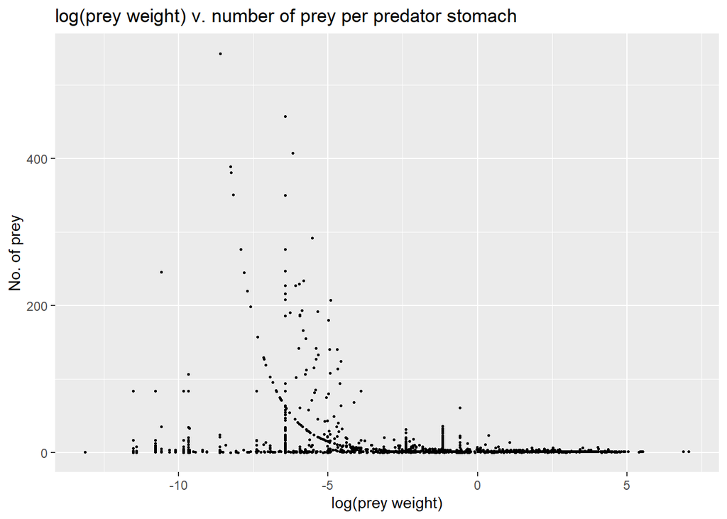

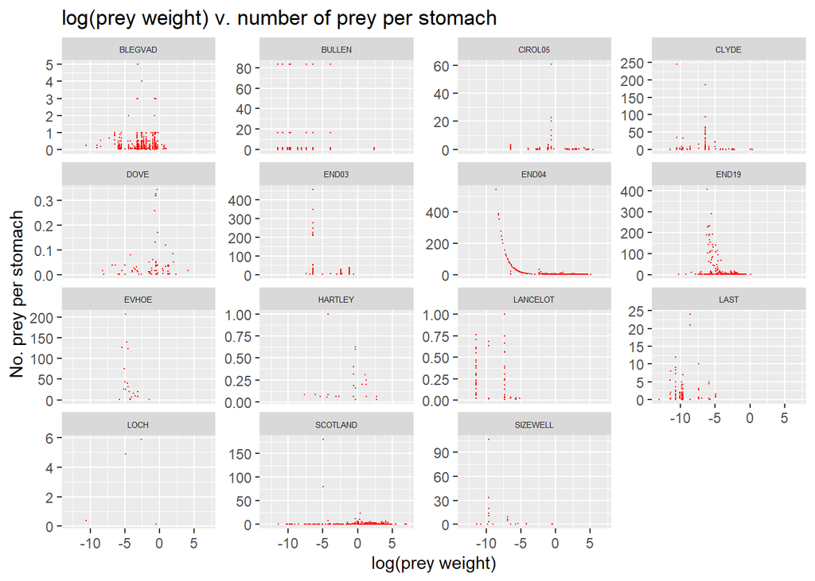

Playing around with data to see any specific correlations; what is the distribution of the weight of prey recorded.

# 5 prey weight v. pred weight

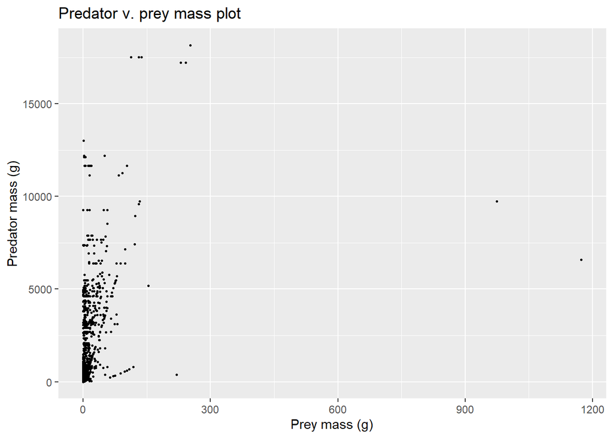

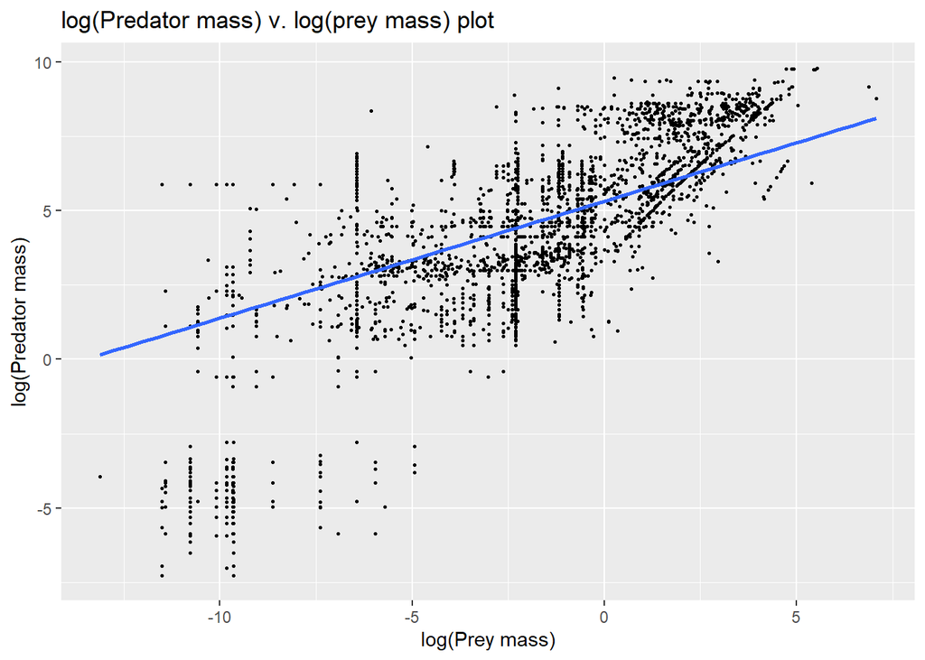

```
## [1] "slope of the log(pred) v. log(prey) line of best fit: 5.32487272201153"
## [2] "slope of the log(pred) v. log(prey) line of best fit: 0.393780579550327"
```

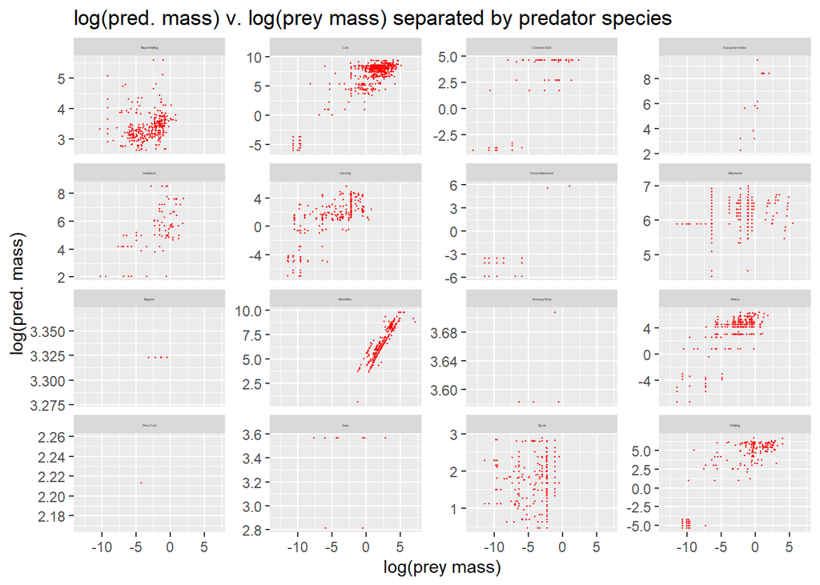

1. Prey weight v. predator weight -> attempting to find a link between the predator mass and the prey mass  
2. log(prey weight) v. log(pred. weight) -> using log() to see proportionality of the axes, slope of added line should = PPMR  
3. Looking to find correlation between the masses for each individual species; the slope should intersect the y-axis at 0, else our idea for PPMR calculation (pred mass is prop. to prey mass) is incorrect

# 6 pred weight v. ppmr

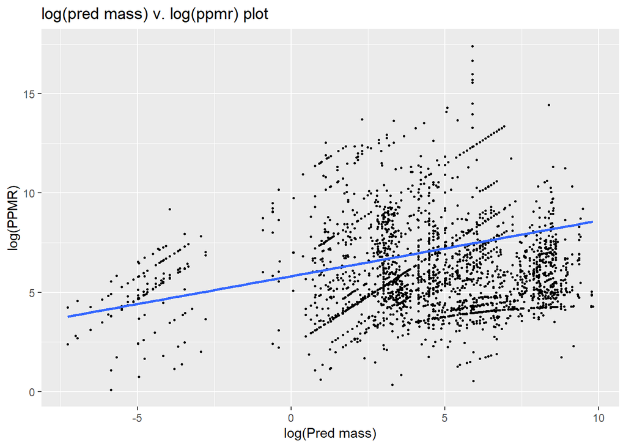

```
## [1] "slope of the log(ppmr) v. log(pred_weight) line of best fit: 5.81167625462212"
## [2] "slope of the log(ppmr) v. log(pred_weight) line of best fit: 0.280065551003071"
```

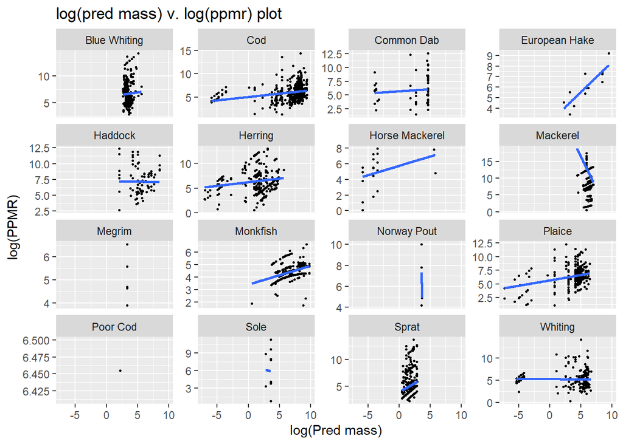

log(pred mass) v. log(ppmr) -> is pred. mass related to ppmr?

We want them to not be proportional (i.e. slope = 0).

CHECK: IS THIS NO. OF POINTS RECORDED OR NO. POINTS*NO. PREY PER STOMACH